# NLP Deliverable

Ana Marin Estañ

# **Madrid’s airbnb reviews, sentiment analysis**

## 0. Select mode

To speed up execution, if sampleReviews variable is set to true (default), only a 1% random sample of the reviews is selected to work with.

```r
sampleReviews = TRUE
```

## 1. Check prerequesites

- Check if all needed packages are installed and added to the library
- Set work directory

```r
options(warn=-1)

packages <- c('rstudioapi',
              'DT',
              'tm',
              'ggplot2',
              'textcat',
              'wordcloud',
              'RWeka',
              'reshape2',
              'tidyverse',
              'tidytext',
              'stringr',
              'dplyr',
              'topicmodels')

install.packages(setdiff(packages, rownames(installed.packages())))
rm(packages)

library(rstudioapi)
library(DT)
library(tm)
library(ggplot2)
library(textcat)
library(wordcloud)
library(RWeka)
library(reshape2)
library(tidyverse)
library(tidytext)
library(stringr)
library(dplyr)
library(topicmodels)
```

```r
setwd(dirname(getActiveDocumentContext()$path ))
cat('Working directory:', getwd())
```

```
Working directory: /Users/Anita/Documents/ANITA/HMDA/1stSemester/Intelligent systems/5.-NLP/NLPHandsOn
```

## 2. Import data and basic exploration

- Import review data form data folder
- Explore number of reviews and features
- Display basic data table

```r
reviews <- read_csv('data/reviews.csv')
cat('Number of reviews:', nrow(reviews), '\nColumn names:', names(reviews))
```

```
Number of reviews: 674987
Column names: listing_id id date reviewer_id reviewer_name comments
```

|  | listing_id | id | date | reviewer_id | reviewer_name | comments |
| --- | --- | --- | --- | --- | --- | --- |
| 1 | 6369 | 29428 | 2010-03-14 | 84790 | Nancy | Simon and Arturo have the ultimate location in Madrid! Steps from the Metro and bus line to everywhere you want to visit. The accomodations are clean, well appointed and fantastic views of Madrid skyl… |
| 2 | 6369 | 31018 | 2010-03-23 | 84338 | David | Myself and Kristy originally planned on staying with Arturo for only a week, but when our plans changed, Arturo was very open to working with our changing schedule. Arturo and Simon were very friendly… |
| 3 | 6369 | 34694 | 2010-04-10 | 98655 | Marion | We had a great time at Arturo and Simon's ! A cosy apartment and a wonderful terrasse, and above all, really nice hosts ! Thank you... |
| 4 | 6369 | 37146 | 2010-04-21 | 109871 | Kurt | I very much enjoyed the stay. It's a wonderful room and bath in a great apartment with a lovely terrace. The location is perfect for me, especially given the easy access to the the Metro and the airpo… |
| 5 | 6369 | 38168 | 2010-04-26 | 98901 | Dennis | Arturo and Simon are polite and friendly hosts who provide a very pleasant and convenient place to stay in Madrid. Dennis |
| 6 | 6369 | 41548 | 2010-05-10 | 95579 | Deborah | Perfect airbnb experience as all others say. Lots of reasonable cafes or places to buy prepared food to eat at home in area. Room with terrace and ensuite prefect. Easy to get to from airport and to g… |
| 7 | 6369 | 42550 | 2010-05-15 | 106586 | Nina | Great host, great apartment! I had the bath to myself which was great. Neighborhood is safe and clean. Convenient store, bank, coffee shop and tapas bar nearby. It's so close you can crawl to it. Over… |
| 8 | 6369 | 45278 | 2010-05-23 | 112662 | Bo | We had a wonderful time in Madrid and the stay at Arturo´s place is recommendable! Especially the terrace is a hit. |
| 9 | 6369 | 45618 | 2010-05-24 | 18688 | Charde | We only stayed here for one night unfortunately, but it was superb value for money. Clean, sunny and spacious with welcoming hosts. It is not in the city centre, but Madrid is easily navigated with th… |
| 10 | 6369 | 57074 | 2010-06-25 | 134713 | Y. S. | Great room in non-touristy location. Convenient to the metro and has lots of tapas bars, bakeries, etc. nearby. |

## 3. Basic data preprocessing

- Limit data to 1% random reviews sample (if selected)
- Detect review language
- Group reviews by language and show 10 most frequent languages
- Keep reviews written in English and Spanish (two most frequent languages) in two different data frames
- Remove empty reviews

```r
if(sampleReviews) {
  reviewsPrep = reviews[sample(nrow(reviews), as.integer(nrow(reviews)/100)),]
} else {
  reviewsPrep = reviews
}

reviewsPrep$language <- textcat(reviewsPrep$comments)
reviewsPrep$language <- as.factor(reviewsPrep$language)

languageCount = count(reviewsPrep, language)
languageCount = languageCount[order(languageCount$n, decreasing = T),]
languageCount$percentage <- (languageCount$n/nrow(reviewsPrep))*100

reviewsEn = reviewsPrep[c(reviewsPrep$language == 'english'),]
reviewsEs = reviewsPrep[c(reviewsPrep$language == 'spanish'),]

reviewsEn = reviewsEn[!(is.na(reviewsEn$comments) | reviewsEn$comments==''), ]
reviewsEs = reviewsEs[!(is.na(reviewsEs$comments) | reviewsEs$comments==''), ]
```

## 4. Corpora creation, inspection and transformations

Two different corpora are created: one containing English reviews, and other with the Spanish ones. First, these corpora are inspected:

- Check length
- Summary of 5 first entries
- Meta and content of first entry

Each of this corpora is preprocessed:

- Transform to lower case
- Remove numbers, Stopwords and punctuation
- Stemming
- Strip white spaces

### English

```r
# Creation and inspection
corpusEn = VCorpus(VectorSource(reviewsEn$comments))
cat('English corpus length:', length(corpusEn), 'entries')
```

```
English corpus length: 2966 entries
```

```r
summary(corpusEn[1:5]); meta(corpusEn[[1]]); content(corpusEn[[1]])
```

```
  Length Class             Mode
1 2      PlainTextDocument list
2 2      PlainTextDocument list
3 2      PlainTextDocument list
4 2      PlainTextDocument list
5 2      PlainTextDocument list
  author       : character(0)
  datetimestamp: 2021-01-05 18:05:25
  description  : character(0)
  heading      : character(0)
  id           : 1
  language     : en
  origin       : character(0)
[1] "For a city trip to Madrid this is the perfect place to stay. It is located very central next to plaza mayor from where you can reach all the nice neighborhoods on foot. The apartment is not that big but we had enough space for five people. It is nicely furnished. The owners are very friendly. I…
```

```r
# Transformation
stopwordsEn = c(stopwords(),'airbnb', 'madrid','stay')
corpusEnT <- tm_map(corpusEn, content_transformer(tolower))
corpusEnT <- tm_map(corpusEnT, content_transformer(removeNumbers))
corpusEnT <- tm_map(corpusEnT, content_transformer(removeWords), stopwordsEn)
corpusEnT <- tm_map(corpusEnT, content_transformer(removePunctuation))
corpusEnT <- tm_map(corpusEnT, content_transformer(stemDocument))
corpusEnT <- tm_map(corpusEnT, content_transformer(stripWhitespace))
```

Original and transformed reviews

```r
corpusEn[['100']][['content']]
```

```
[1] "Patricia was a great host. The room and apartment were extremely clean, we loved it. The location is perfect, in the center of La Latina -perfect to go out and have drinks-, near the Plaza Mayor and the Royal Palace (10-15 min by foot). We had a good and typical breakfast in the local market th…
```

```r
corpusEnT[['100']][['content']]
```

```
[1] "patricia great host room apart extrem clean love locat perfect center la latina perfect go drink near plaza mayor royal palac min foot good typic breakfast local market just two block far away total recommend patricia room"
```

### Spanish

```r
# Creation and inspection
corpusEs = VCorpus(VectorSource(reviewsEs$comments))
cat('Spanish corpus length:', length(corpusEs), 'entries')
```

```
Spanish corpus length: 2486 entries
```

```r
summary(corpusEs[1:5]); meta(corpusEs[[1]]); content(corpusEs[[1]])
```

```
  Length Class             Mode
1 2      PlainTextDocument list
2 2      PlainTextDocument list
3 2      PlainTextDocument list
4 2      PlainTextDocument list
5 2      PlainTextDocument list
  author       : character(0)
  datetimestamp: 2021-01-05 18:05:32
  description  : character(0)
  heading      : character(0)
  id           : 1
  language     : en
  origin       : character(0)
[1] "Elsa y Gustavo son excelentes anfitriones y lindas personas; desde el primer contacto hasta sus atenciones al recibirnos; nos dieron muchos consejos, la habitación estaba excelentemente limpia y la cama muy cómoda; excelente ubicación, cerca del aeropuerto, parada de bus a unos pasos sobre la m…
```

```r
# Transformation
stopwordsEs = c(stopwords('spanish'), 'madrid', 'airbnb')
corpusEsT <- tm_map(corpusEs, content_transformer(tolower))
corpusEsT <- tm_map(corpusEsT, content_transformer(removeNumbers))
corpusEsT <- tm_map(corpusEsT, content_transformer(removeWords), stopwordsEs)
corpusEsT <- tm_map(corpusEsT, content_transformer(removePunctuation))
corpusEsT <- tm_map(corpusEsT, content_transformer(stemDocument))
corpusEsT <- tm_map(corpusEsT, content_transformer(stripWhitespace))
```

Original and transformed reviews

```r
corpusEs[['50']][['content']]
```

```
[1] "Apartamento de 10, bien ubicado y precioso."
```

```r
corpusEsT[['50']][['content']]
```

```
[1] "apartamento bien ubicado precioso"
```

## 5. Create TDM

In this section Term-Document matrixes are created with TF-IDF weighting

```r
tdmEn = TermDocumentMatrix(corpusEnT, control = list(weighting = weightTfIdf))
tdmEn
```

```
<<TermDocumentMatrix (terms: 4924, documents: 2966)>>
Non-/sparse entries: 67102/14537482
Sparsity           : 100%
Maximal term length: 1140
Weighting          : term frequency - inverse document frequency (normalized) (tf-idf)
```

```r
tdmEs = TermDocumentMatrix(corpusEsT, control = list(weighting = weightTfIdf))
tdmEs
```

```
<<TermDocumentMatrix (terms: 5179, documents: 2486)>>
Non-/sparse entries: 38563/12836431
Sparsity           : 100%
Maximal term length: 128
Weighting          : term frequency - inverse document frequency (normalized) (tf-idf)
```

## 6. Basic text analysis

- Language analysis
- TF-IDF word frequencies (Zipf’s law comporbation)
- Word clouds
- Most frequent word associations

```r
# Adpaat params to number of reviews
if(sampleReviews) {
  maxWords = 100
  lowFreqEn = 1000
  lowFreqEs = 500
} else {
  maxWords = 10000
  lowFreqEn = 100000
  lowFreqEs = 50000
}
```

```r
# Language analysis
languageCount[1:10,]
```

| language | n | percentage |
| --- | --- | --- |
| english | 2966 | 43.9472514 |
| spanish | 2486 | 36.8350867 |
| french | 421 | 6.2379612 |
| portuguese | 168 | 2.4892577 |
| italian | 140 | 2.0743814 |
| scots | 98 | 1.4520670 |
| german | 70 | 1.0371907 |
| catalan | 54 | 0.8001185 |
| russian-windows1251 | 48 | 0.7112165 |
| latin | 30 | 0.4445103 |

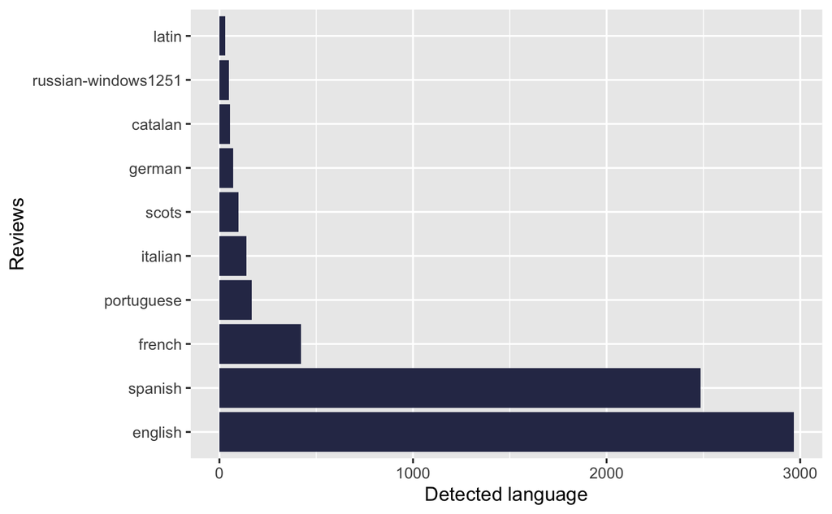

```r
p <- ggplot(data=select(languageCount[1:10, ], language, n), aes(x=reorder(language, -n), y=n)) +
  geom_bar(stat='identity', fill='#2F3456')
p + xlab('Reviews') +
  ylab('Detected language') +
  coord_flip()
```

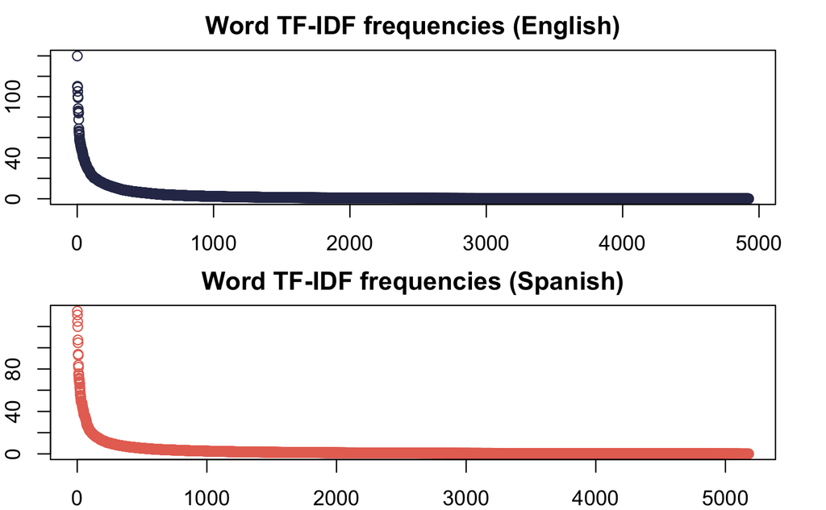

```r
#TF-IDF Zipf's law
freqEn=rowSums(as.matrix(tdmEn))
freqEs=rowSums(as.matrix(tdmEs))
par(mfrow=c(2,1), mar = c(2, 2, 2, 2))
plot(sort(freqEn, decreasing = TRUE), col='#2F3456', xlab='TF-IDF-based rank', ylab = 'TF-IDF', main='Word TF-IDF frequencies (English)')
plot(sort(freqEs, decreasing = TRUE), col='#E77161', xlab='TF-IDF-based rank', ylab = 'TF-IDF', main='Word TF-IDF frequencies (Spanish)')
```

```r
print('10 most relevant words in English:'); tail(sort(freqEn),n=10)
```

```
[1] "10 most relevant words in English:"
recommend   perfect     clean      good      host     locat     apart     place
 83.96020  85.19740  86.05774  88.37371  99.05645 100.14641 105.18940 109.36650
     nice     great
110.24522 139.88083
```

```r
print('10 most relevant words in Spanish:'); tail(sort(freqEs),n=10)
```

```
[1] "10 most relevant words in Spanish:"
      amabl        piso      limpio       lugar apartamento    recomend
   81.69622    83.59504    92.94761    93.88279   104.71635   107.36648
      buena        bien   ubicación    excelent
  119.93396   124.74817   130.91532   134.55883
```

```r
#Word Clouds
par(mfrow=c(1,1))

unigramTokenizer <- function(x) NGramTokenizer(x, Weka_control(min = 1, max = 1))
tdmEn.unigram = TermDocumentMatrix(corpusEnT,
                                control = list (weighting = weightTfIdf,
                                                tokenize = unigramTokenizer))
tdmEs.unigram = TermDocumentMatrix(corpusEsT,
                                   control = list (weighting = weightTfIdf,
                                                   tokenize = unigramTokenizer))
```

```r
# Plot English Wordcloud
freqEn = sort(rowSums(as.matrix(tdmEn.unigram)),decreasing = TRUE)
freqEn.df = data.frame(word=names(freqEn), freq=freqEn)
layout(matrix(c(1, 2), nrow=2), heights=c(1, 10))
par(mar=rep(0, 4))
plot.new()
text(x=0.5, y=0.5, "English wordcloud", cex=1.5,font=2)
```

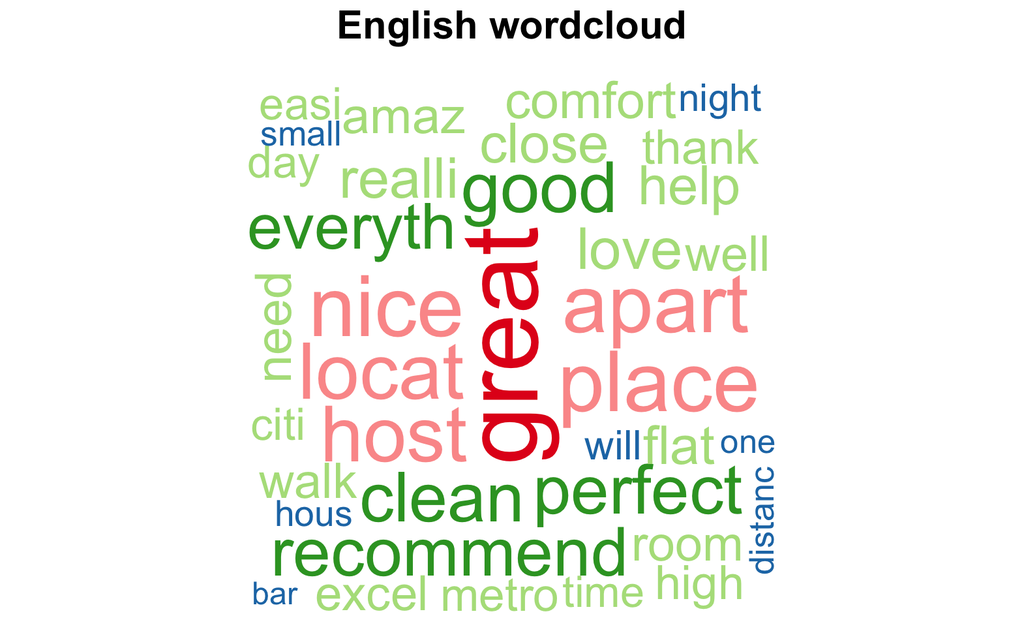

```r
wordcloud(freqEn.df$word,freqEn.df$freq,max.words=maxWords,random.order = FALSE, colors=brewer.pal(6,'Paired'))
```

```r
# Plot Spanish Wordcloud
freqEs = sort(rowSums(as.matrix(tdmEs.unigram)),decreasing = TRUE)
freqEs.df = data.frame(word=names(freqEs), freq=freqEs)
layout(matrix(c(1, 2), nrow=2), heights=c(1, 10))
par(mar=rep(0, 4))
plot.new()
text(x=0.5, y=0.5, "Spanish wordcloud", cex=1.5,font=2)
```

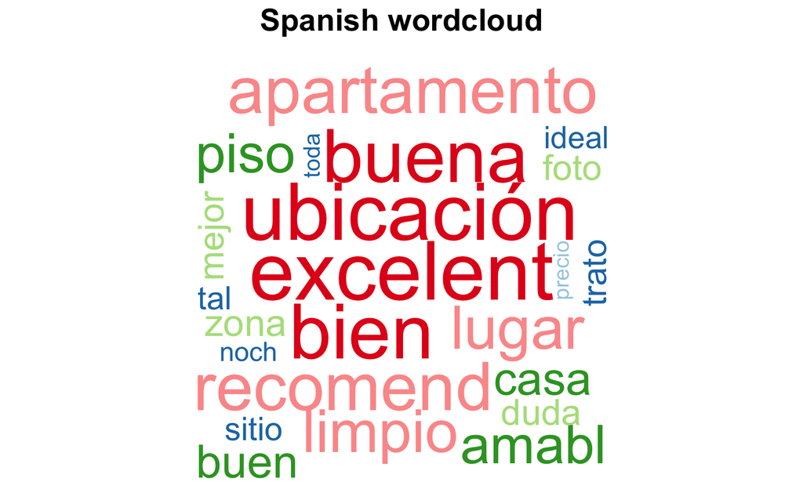

```r
wordcloud(freqEs.df$word,freqEs.df$freq,max.words=maxWords,random.order = FALSE, colors=brewer.pal(6,'Paired'))
```

```r
#Word frequencies and associations
dtmEn <- DocumentTermMatrix(corpusEnT)
dtmEs <- DocumentTermMatrix(corpusEsT)

freqTermEn = findFreqTerms(dtmEn, lowfreq = lowFreqEn)
assocEn = findAssocs(dtmEn, terms = freqTermEn, corlimit = 0.15)
freqTermEn
```

```
[1] "apart" "great" "locat" "place"
```

```r
assocEn
```

```
$apart
   walk  cooker    need    even restaur     two   quick  street    well     bed
   0.22    0.19    0.19    0.18    0.18    0.18    0.17    0.17    0.17    0.16
   door kitchen  machin   minut  shower   arriv   coffe    show
   0.16    0.16    0.16    0.16    0.16    0.15    0.15    0.15

$great
  factor feelgood
    0.18     0.18

$locat
numeric(0)

$place
 eat
0.16
```

```r
freqTermEs = findFreqTerms(dtmEs, lowfreq = lowFreqEs)
assocEs = findAssocs(dtmEs, terms = freqTermEs, corlimit = 0.15)
freqTermEs
```

```
[1] "apartamento" "bien"        "excelent"    "ubicación"
```

```r
assocEs
```

```
$apartamento
        peor         anti     anticuca    aparecían        debía  defendiendo
        0.24         0.23         0.23         0.23         0.23         0.23
    disculpa     enviando    evidencia      forzada        fruto      horribl
        0.23         0.23         0.23         0.23         0.23         0.23
   intentamo   marineando    olvidarlo      plagada       prueba       quedan
        0.23         0.23         0.23         0.23         0.23         0.23
 solucionado        venía   vídeosfoto       vieron       pagado    cucaracha
        0.23         0.23         0.23         0.23         0.22         0.21
solucionarlo       cocina         hora      cambiar        covid     encimera
        0.18         0.17         0.17         0.16         0.16         0.16
       fondo      informó  inicialment         irno         sola        spray
        0.16         0.16         0.16         0.16         0.16         0.16

$bien
     ubicado      situado   comunicado       plegar     equipado   bullicioso
        0.32         0.25         0.23         0.21         0.17         0.16
   cochecito    discusion   enganchado  gestionarlo        hagan        llego
        0.16         0.16         0.16         0.16         0.16         0.16
 matrimonial matrimonial…    minúsculo     reclamar     trajeron       vaciar
        0.16         0.16         0.16         0.16         0.16         0.16

$excelent
numeric(0)

$ubicación
buena
 0.22
```

## 7. Sentiment analysis

- General trends
- Most polarized reviews
- Most sentiment-contributing terms

```r
# Adpaat params to number of reviews
if(sampleReviews) {
  termFreq = 40
} else {
  termFreq = 1500
}
```

```r
#Get sentiments data frame
dtmEnTidy <- tidy(dtmEn)
sentimentsEn <- dtmEnTidy %>%
  inner_join(get_sentiments('bing'), by = c(term = 'word'))

positiveWordsEs <- read_csv('es_lexicons/positive_words_es.txt', col_names = "term") %>%
  mutate(sentiment = "positive")
negativeWordsEs <- read_csv('es_lexicons/negative_words_es.txt', col_names = "term") %>%
  mutate(sentiment = "negative")
sentimentWordsEs <- bind_rows(positiveWordsEs, negativeWordsEs)

dtmEsTidy <- tidy(dtmEs)
sentimentsEs <- dtmEsTidy %>%
  inner_join(sentimentWordsEs) %>%
  count(document, term, sentiment, sort = TRUE) %>%
  ungroup()
names(sentimentsEs)[4] <- 'count'
```

### English

```r
#General trends
sentimentsEn %>%
  count(sentiment, wt = count) %>%
  spread(sentiment, n, fill = 0) %>%
  mutate(sentiment = positive - negative) %>%
  arrange(-sentiment)
```

| negative | positive | sentiment |
| --- | --- | --- |
| 962 | 11699 | 10737 |

```r
# Find most positive reviews
posRevs <- sentimentsEn %>%
  count(document, sentiment, wt = count) %>%
  spread(sentiment, n, fill = 0) %>%
  mutate(sentiment = positive - negative) %>%
  arrange(-sentiment)
  head(posRevs)
```

| document | negative | positive | sentiment |
| --- | --- | --- | --- |
| 825 | 0 | 24 | 24 |
| 1845 | 2 | 25 | 23 |
| 2215 | 0 | 23 | 23 |
| 1917 | 1 | 20 | 19 |
| 570 | 0 | 19 | 19 |
| 1500 | 1 | 19 | 18 |

```r
# Inspect most positive doc
sentimentsEn %>%
  filter(document == posRevs$document[1]) %>%
  arrange(-count)
```

| document | term | count | sentiment |
| --- | --- | --- | --- |
| 825 | nice | 3 | positive |
| 825 | pleasant | 2 | positive |
| 825 | super | 2 | positive |
| 825 | well | 2 | positive |
| 825 | work | 2 | positive |
| 825 | comfort | 1 | positive |
| 825 | cool | 1 | positive |
| 825 | good | 1 | positive |
| 825 | great | 1 | positive |
| 825 | hot | 1 | positive |

[output cut: 8 more lines]

```r
corpusEn[[posRevs$document[1]]][['content']]
```

```
[1] "I spent a few days in Almudena's flat and it was all great and pleasant!  I was welcomed for the check-in by her dad who is  super nice and kind. The flat is in a beautiful building with lift and also porter. It is all new and decorated nicely. The flat has both radiators and A/C and having bee…
```

```r
# Find most negative reviews
negRevs <- sentimentsEn %>%
  count(document, sentiment, wt = count) %>%
  spread(sentiment, n, fill = 0) %>%
  mutate(sentiment = positive - negative) %>%
  arrange(sentiment)
 head(negRevs)
```

| document | negative | positive | sentiment |
| --- | --- | --- | --- |
| 994 | 7 | 2 | -5 |
| 1222 | 6 | 2 | -4 |
| 2416 | 4 | 0 | -4 |
| 1417 | 3 | 0 | -3 |
| 1447 | 3 | 0 | -3 |
| 1611 | 6 | 3 | -3 |

```r
# Inspect most negative doc
sentimentsEn %>%
  filter(document == negRevs$document[1]) %>%
  arrange(-count)
```

| document | term | count | sentiment |
| --- | --- | --- | --- |
| 994 | bother | 1 | negative |
| 994 | disappoint | 1 | negative |
| 994 | dust | 1 | negative |
| 994 | famous | 1 | positive |
| 994 | good | 1 | positive |
| 994 | jam | 1 | negative |
| 994 | miss | 1 | negative |
| 994 | problem | 1 | negative |
| 994 | sink | 1 | negative |

```r
corpusEn[[negRevs$document[1]]][['content']]
```

```
[1] "I was a bit disappointed as the place was advertised as new but the room I was in just had a splash of white paint. \n\nLysh my host did not bother to explain a few things and there were lots of basic breakfast items missing from the included breakfast as listed. There was no sugar, milk, butte…
```

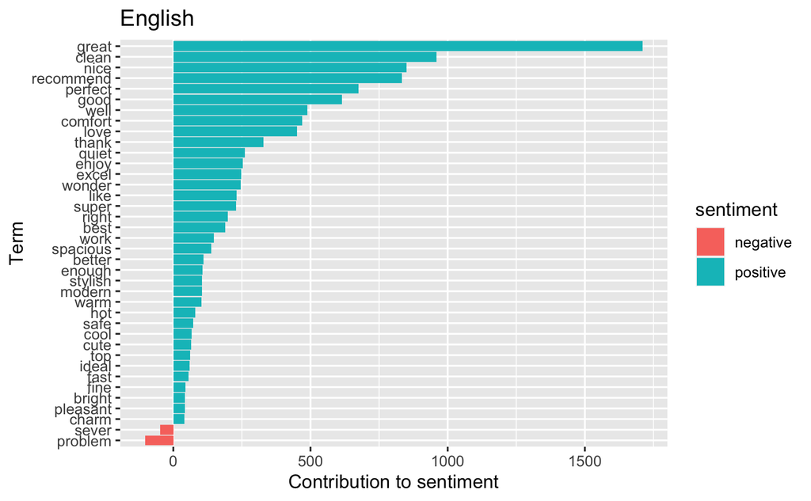

```r
# Most sentiment-contributive words
sentimentsEn %>%
  count(sentiment, term, wt = count) %>%
  filter(n >= termFreq) %>%
  mutate(n = ifelse(sentiment == 'negative', -n, n)) %>%
  mutate(term = reorder(term, n)) %>%
  ggplot(aes(term, n, fill = sentiment)) +
  geom_bar(stat = 'identity') +
  coord_flip() +
  geom_col() +
  theme() +
  labs(x = 'Term', y = 'Contribution to sentiment',  title = 'English')
```

### Spanish

```r
# General trends
sentimentsEs %>%
  count(sentiment, wt = count) %>%
  spread(sentiment, n, fill = 0) %>%
  mutate(sentiment = positive - negative) %>%
  arrange(-sentiment)
```

| negative | positive | sentiment |
| --- | --- | --- |
| 2236 | 6771 | 4535 |

```r
# Find most positive reviews
posRevs <- sentimentsEs %>%
  count(document, sentiment, wt = count) %>%
  spread(sentiment, n, fill = 0) %>%
  mutate(sentiment = positive - negative) %>%
  arrange(-sentiment)
head(posRevs)
```

| document | negative | positive | sentiment |
| --- | --- | --- | --- |
| 1987 | 4 | 16 | 12 |
| 2430 | 2 | 14 | 12 |
| 689 | 2 | 14 | 12 |
| 1816 | 1 | 11 | 10 |
| 2229 | 0 | 10 | 10 |
| 76 | 3 | 13 | 10 |

```r
# Inspect most positive doc
sentimentsEs %>%
  filter(document == posRevs$document[1]) %>%
  arrange(-count)
```

| document | term | sentiment | count |
| --- | --- | --- | --- |
| 1987 | atento | positive | 1 |
| 1987 | bien | positive | 1 |
| 1987 | bienvenida | positive | 1 |
| 1987 | bienvenido | positive | 1 |
| 1987 | cómoda | negative | 1 |
| 1987 | completo | positive | 1 |
| 1987 | ganado | positive | 1 |
| 1987 | gracia | positive | 1 |
| 1987 | gran | positive | 1 |
| 1987 | indicado | positive | 1 |

[output cut: 10 more lines]

```r
corpusEs[[posRevs$document[1]]][['content']]
```

```
[1] "Fernando se ha ganado el título de superhost a pulso, siempre súper atento desde nuestra llegada y nos ayudó en todo, inclusive con un problema que  tuvimos en el aeropuerto con una maleta, siempre servicial, desayuno completo, él es muy ameno y detallista, nos dio un gran recibimiento en su ho…
```

```r
# Find most negative reviews
negRevs <- sentimentsEs %>%
  count(document, sentiment, wt = count) %>%
  spread(sentiment, n, fill = 0) %>%
  mutate(sentiment = positive - negative) %>%
  arrange(sentiment)
head(negRevs)
```

| document | negative | positive | sentiment |
| --- | --- | --- | --- |
| 23 | 12 | 4 | -8 |
| 1225 | 5 | 1 | -4 |
| 1880 | 5 | 1 | -4 |
| 354 | 7 | 3 | -4 |
| 445 | 4 | 0 | -4 |
| 869 | 6 | 2 | -4 |

```r
# Inspect most negative doc
sentimentsEs %>%
  filter(document == negRevs$document[1]) %>%
  arrange(-count)
```

| document | term | sentiment | count |
| --- | --- | --- | --- |
| 23 | alergia | negative | 1 |
| 23 | bueno | positive | 1 |
| 23 | completo | positive | 1 |
| 23 | duda | negative | 1 |
| 23 | educación | positive | 1 |
| 23 | falta | negative | 1 |
| 23 | gran | positive | 1 |
| 23 | papelera | negative | 1 |
| 23 | peligroso | negative | 1 |
| 23 | peor | negative | 1 |

[output cut: 6 more lines]

```r
corpusEs[[negRevs$document[1]]][['content']]
```

```
[1] "Bueno de las peores estancias en la que he estado en mi vida sin duda. Empezando por la anfitriona que a pesar de tenerla que llamar muchas veces para que nos atendiera el teléfono, nos atendió con una actitud totalmente desagradable y chulesca, sin educación y sin ser nada amable. Cuando por f…
```

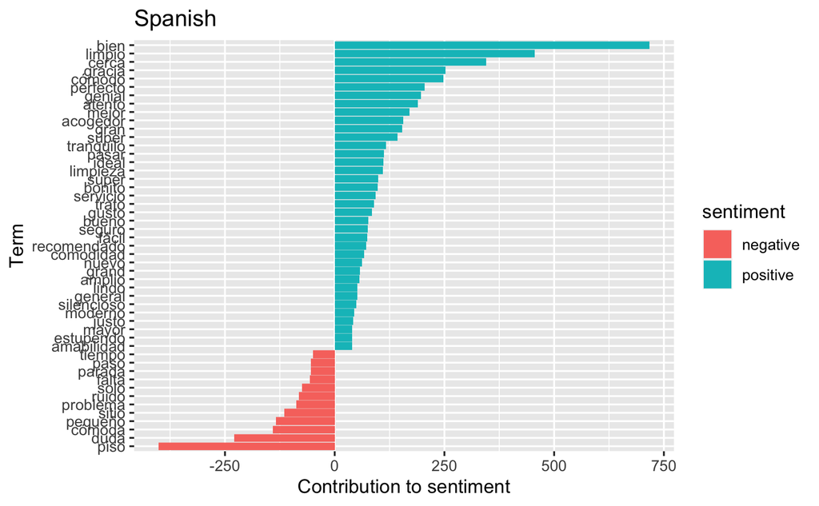

```r
# Most sentiment-contributive words
sentimentsEs %>%
  count(sentiment, term, wt = count) %>%
  filter(n >= termFreq) %>%
  mutate(n = ifelse(sentiment == 'negative', -n, n)) %>%
  mutate(term = reorder(term, n)) %>%
  ggplot(aes(term, n, fill = sentiment)) +
  geom_bar(stat = 'identity') +
  coord_flip() +
  geom_col() +
  theme() +
  labs(x = "Term", y = 'Contribution to sentiment',  title = "Spanish")
```